**Rotating Machinery**

By Prof. Seungchul Lee  
http://iai.postech.ac.kr/  
Industrial AI Lab at POSTECH

Table of Contents

# 1. Data from Our Testbed

- unbalance.mat $\implies$ [01 02 03 04]
  - 01 = 시간
  - 02 = 불균형이 거의 없는 경우 진동 (정상)
  - 03 = 불균형이 있는 경우 진동 (1X성분이 증가) 3.6g * 44.4mm
  - 04 = 불균형이 더 심한 경우 진동 (1X성분이 매우 증가) 5.6g * 44.4mm :

```matlab
filename = '.\data_files\unbalance.mat';
data = load(filename);
```

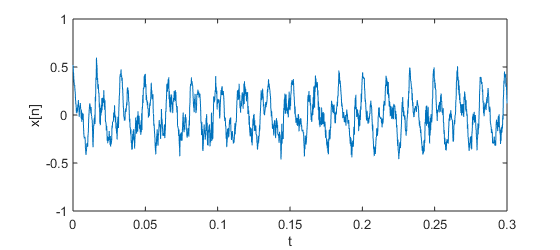

```matlab
%plot -s 560,250

time = data.unbalance(:,1);
x = data.unbalance(:,4);

plot(time,x), xlim([0,0.3]), ylim([-1,1]), xlabel('t'), ylabel('x[n]')
```

# 2. Feature Extraction

## 2.1. Feature Extraction from Time Domain

**Moments of a signal: mean, variance, skewness, and kurtosis**

- mean

$$\bar x = \frac{1}{N} \sum_{n=1}^{N} x[n]$$

- variance

$$\text{var} (x) = \frac{1}{N-1} \sum_{n=1}^{N} (x[n] - \bar x)^2$$$$\sigma = \sqrt{\text{var}}$$

- Note: RMS (root mean square)

$$\text{RMS} = \sqrt{\frac{1}{N} \sum_{n=1}^{N}x[n]^2 } = \sqrt{\bar x ^2 + \sigma^2}$$

[figure not shown]

- Skewness
  - a positive value of skewness signifies a distribution with an asymmetric tail extending out towards more positive $x$
  - a negative value signifies a distribution whose tail extends out towards more negative $x$

$$\text{skewness} (x) = \frac{1}{N} \sum_{n=1}^{N} \left(\frac{x[n] - \bar x}{\sigma} \right)^3$$

- Kurtosis
  - It measures the relative peakedness or flatness of a distribution. Relative to what? A normal distribution

$$\text{kurtosis} (x) = \frac{1}{N} \sum_{n=1}^{N} \left(\frac{x[n] - \bar x}{\sigma} \right)^4 - 3$$

$\qquad \quad$where the $−3$ term makes the value zero for a normal distribution.

```matlab
% mean
mean(x)

% variance
var(x)

% rms
rms(x)

% skewness
skewness(x)

% kurtosis
kurtosis(x)
```

```
ans =

   2.2665e-04


ans =

    0.0403


ans =

    0.2008


ans =

    0.1691


ans =

    2.3759
```

**Waveform related features**

- Crest factor

$$\frac{x_{\max}}{x_{\text{rms}}}$$

- Impulse factor

$$\frac{x_{\max}}{x_{\text{mean}}}$$

- Shape factor

$$\frac{x_{\text{rms}}}{x_{\text{mean}}}$$

```matlab
% crest factor
max(x)/rms(x)

% impulse factor
max(x)/mean(x)

% shape factor
rms(x)/mean(x)
```

```
ans =

    3.0229


ans =

   2.6780e+03


ans =

  885.9082
```

## 2.2. Feature Extraction from Frequency Domain

Ampliutes at the specific frequencies

- Harmonics/subharmonics ($1X,\;2X,\;3X, \cdots$)
- BPFI (ball pass frequency inner race)

$$\text{BPFI} = \frac{N}{2} \times F \times \left( 1 + \frac{B}{P} \cos \theta \right)$$

- BPFO (ball pass frequency outer race)

$$\text{BPFO} = \frac{N}{2} \times F \times \left( 1 - \frac{B}{P} \cos \theta \right)$$

- BSF (ball spin frequency)

$$\text{BSF} = \frac{P}{2B} \times F \times \left[ 1 - \left( \frac{B}{P} \cos \theta \right)^2 \right]$$

- BDF (ball defect frequency)

$$\text{BDF} = 2 \times \text{BSF} = \frac{P}{B} \times F \times \left[ 1 - \left( \frac{B}{P} \cos \theta \right)^2 \right]$$

```matlab
T = time(2) - time(1);
Fs = 1/T;

N = length(time);
L = N/Fs;
t = 0:T:time(end);
```

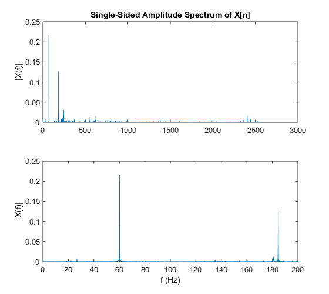

```matlab
%plot -s 560,500

% single-sided fft
xt = fft(x)/N;
xtss = xt(1:N/2+1);
xtss(2:end-1) = 2*xtss(2:end-1);

k = [0:N-1];
f = (Fs/N)*k;
fss = f(1:N/2+1);

% plot
subplot(2,1,1), plot(fss,abs(xtss))
title('Single-Sided Amplitude Spectrum of X[n]')
ylabel('|X(f)|')

subplot(2,1,2), plot(fss,abs(xtss)), xlim([0,200])
xlabel('f (Hz)')
ylabel('|X(f)|')
```

$$X_{\text{feature vector}} = \text{amplitude at the specific frequency}$$

```matlab
amplitude = abs(xtss)';

BPFO = 183.183;
c = 20;

filter01 = zeros(1,length(fss));
filter01([ceil(N/Fs*(BPFO-c)):ceil(N/Fs*(BPFO+c))]) = 1;

X1 = max(amplitude.*filter01)
```

```
X1 =

    0.1278
```

# 3. Fault Modes

- unbalance.mat $\implies$ [01 02 03 04]
  - 01 = 시간
  - 02 = 불균형이 거의 없는 경우 진동 (정상)
  - 03 = 불균형이 있는 경우 진동 (1X성분이 증가) 3.6g * 44.4mm
  - 04 = 불균형이 더 심한 경우 진동 (1X성분이 매우 증가) 5.6g * 44.4mm :
- misalign.mat $\implies$ [01 02 03]
  - 01 = 시간
  - 02 = 불균형이 있는 경우 (1X성분이 증가) 3.6g * 44.4mm
  - 03 = 불균형이 있으면서, 정렬불량이 심한 경우 (2X 성분이 크게 증가) - 2mm 정렬불량
- outerrace_fault $\implies$ [01 02 03 04]
  - 01 = 시간
  - 02 = 불균형이 있는 경우 (1X성분이 증가) 3.6g * 44.4mm
  - 03 = 불균형이 있으면서, 외륜결함이 있는 경우
  - 04 = 불균형이 있으면서, 외륜결함으로 구동 중 베어링이 파손된 경우
- innerace_fault $\implies$ [01 02 03 04]
  - 01 = 시간
  - 02 = 불균형이 있는 경우 (1X성분이 증가) 3.6g * 44.4mm
  - 03 = 불균형이 있으면서, 내륜결함이 있는 경우
  - 04 = 불균형이 있으면서, 내륜결함으로 구동 중 베어링이 파손된 경우

## 3.1. Unbalance

- unbalance.mat $\implies$ [01 02 03 04]
  - 01 = 시간
  - 02 = 불균형이 거의 없는 경우 진동 (정상)
  - 03 = 불균형이 있는 경우 진동 (1X성분이 증가) 3.6g * 44.4mm
  - 04 = 불균형이 더 심한 경우 진동 (1X성분이 매우 증가) 5.6g * 44.4mm :

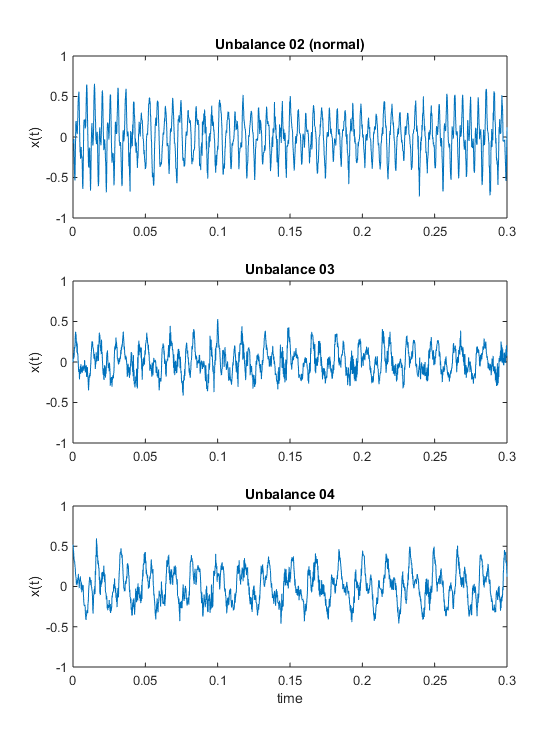

```matlab
%plot -s 560,750

filename = '.\data_files\unbalance.mat';
data = load(filename);

time = data.unbalance(:,1);
unbal02 = data.unbalance(:,2);
unbal03 = data.unbalance(:,3);
unbal04 = data.unbalance(:,4);

subplot(3,1,1), plot(time,unbal02), xlim([0,0.3]), ylim([-1,1])
title('Unbalance 02 (normal)'), ylabel('x(t)')
subplot(3,1,2), plot(time,unbal03), xlim([0,0.3]), ylim([-1,1])
title('Unbalance 03'), ylabel('x(t)')
subplot(3,1,3), plot(time,unbal04), xlim([0,0.3]), ylim([-1,1])
title('Unbalance 04'), xlabel('time'), ylabel('x(t)')
```

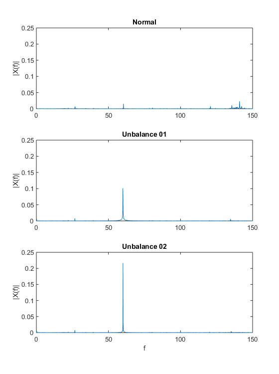

```matlab
%plot -s 560,750

T = time(2) - time(1);
Fs = 1/T;
N = length(time);
L = N/Fs;
t = 0:T:time(end);

% single-sided fft
ut2 = fft(unbal02)/N;
ut2ss = ut2(1:N/2+1);
ut2ss(2:end-1) = 2*ut2ss(2:end-1);

ut3 = fft(unbal03)/N;
ut3ss = ut3(1:N/2+1);
ut3ss(2:end-1) = 2*ut3ss(2:end-1);

ut4 = fft(unbal04)/N;
ut4ss = ut4(1:N/2+1);
ut4ss(2:end-1) = 2*ut4ss(2:end-1);

k = [0:N-1];
f = (Fs/N)*k;
fss = f(1:N/2+1);

% plot
subplot(3,1,1), plot(fss,abs(ut2ss)), ylim([0,0.25]), xlim([0,150])
title('Normal'), ylabel('|X(f)|')

subplot(3,1,2), plot(fss,abs(ut3ss)), ylim([0,0.25]), xlim([0,150])
title('Unbalance 01'), ylabel('|X(f)|')

subplot(3,1,3), plot(fss,abs(ut4ss)), ylim([0,0.25]), xlim([0,150])
title('Unbalance 02'), ylabel('|X(f)|'), xlabel('f')
```

## 3.2. Misalignment

- misalign.mat $\implies$ [01 02 03]
  - 01 = 시간
  - 02 = 불균형이 있는 경우 (1X성분이 증가) 3.6g * 44.4mm
  - 03 = 불균형이 있으면서, 정렬불량이 심한 경우 (2X 성분이 크게 증가) - 2mm 정렬불량

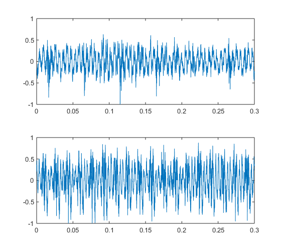

```matlab
%plot -s 560,500

filename = '.\data_files\misalign.mat';
data = load(filename);

time = data.misalign(:,1);
misalign02 = data.misalign(:,2);
misalign03 = data.misalign(:,3);

subplot(2,1,1), plot(time,misalign02), xlim([0,0.3]), ylim([-1,1])
subplot(2,1,2), plot(time,misalign03), xlim([0,0.3]), ylim([-1,1])
```

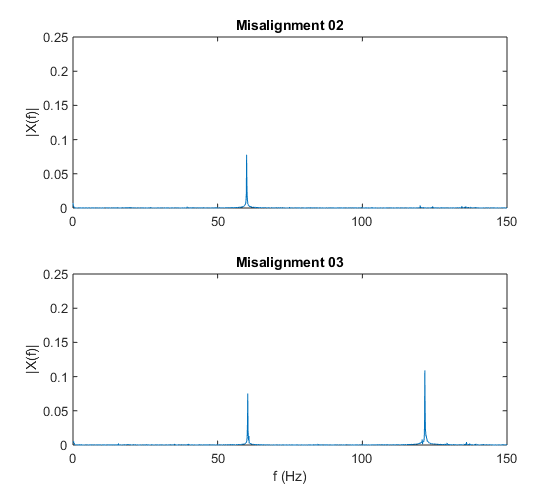

```matlab
%plot -s 560,500

T = time(2) - time(1);
Fs = 1/T;
N = length(time);
L = N/Fs;
t = 0:T:time(end);

% single-sided fft
mt2 = fft(misalign02)/N;
mt2ss = mt2(1:N/2+1);
mt2ss(2:end-1) = 2*mt2ss(2:end-1);

mt3 = fft(misalign03)/N;
mt3ss = mt3(1:N/2+1);
mt3ss(2:end-1) = 2*mt3ss(2:end-1);

k = [0:N-1];
f = (Fs/N)*k;
fss = f(1:N/2+1);

% plot
subplot(2,1,1), plot(fss,abs(mt2ss)), ylim([0,0.25]), xlim([0,150])
title('Misalignment 02'), ylabel('|X(f)|')
subplot(2,1,2), plot(fss,abs(mt3ss)), ylim([0,0.25]), xlim([0,150])
title('Misalignment 03'), xlabel('f (Hz)'), ylabel('|X(f)|')
```

## 3.3. Outer Race

- outerrace_fault $\implies$ [01 02 03 04]
  - 01 = 시간
  - 02 = 불균형이 있는 경우 (1X성분이 증가) 3.6g * 44.4mm
  - 03 = 불균형이 있으면서, 외륜결함이 있는 경우
  - 04 = 불균형이 있으면서, 외륜결함으로 구동 중 베어링이 파손된 경우

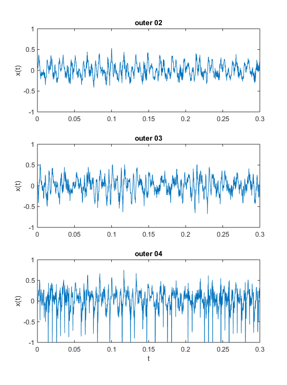

```matlab
%plot -s 560,750

filename = '.\data_files\outerrace_fault.mat';
data = load(filename);

time = data.outer(:,1);
out02 = data.outer(:,2);
out03 = data.outer(:,3);
out04 = data.outer(:,4);

subplot(3,1,1), plot(time,out02), xlim([0,0.3]), ylim([-1,1]), ylabel('x(t)'), title('outer 02')
subplot(3,1,2), plot(time,out03), xlim([0,0.3]), ylim([-1,1]), ylabel('x(t)'), title('outer 03')
subplot(3,1,3), plot(time,out04), xlim([0,0.3]), ylim([-1,1]), xlabel('t'), ylabel('x(t)'), title('outer 04')
```

```matlab
T = time(2) - time(1);
Fs = 1/T;
N = length(time);
L = N/Fs;
t = 0:T:time(end);

% single-sided fft
ot2 = fft(out02)/N;
ot2ss = ot2(1:N/2+1);
ot2ss(2:end-1) = 2*ot2ss(2:end-1);

ot3 = fft(out03)/N;
ot3ss = ot3(1:N/2+1);
ot3ss(2:end-1) = 2*ot3ss(2:end-1);

ot4 = fft(out04)/N;
ot4ss = ot4(1:N/2+1);
ot4ss(2:end-1) = 2*ot4ss(2:end-1);

k = [0:N-1];
f = (Fs/N)*k;
fss = f(1:N/2+1);
```

```matlab
BSF = 119.621;
BPFO = 183.183;
BDF = 239.242;
BPFI = 296.817;
```

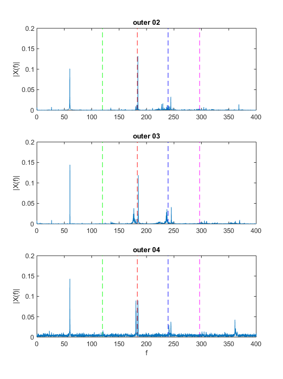

```matlab
%plot -s 560,750

subplot(3,1,1), plot([BSF,BSF],[0,0.2],'--g',[BPFO,BPFO],[0,0.2],'--r',[BDF,BDF],[0,0.2],'--b',[BPFI,BPFI],[0,0.2],'--m'),
hold on, plot(fss,abs(ot2ss)), hold off, xlim([0,400]), ylim([0,0.2]), ylabel('|X(f)|'), title('outer 02')

subplot(3,1,2), plot([BSF,BSF],[0,0.2],'--g',[BPFO,BPFO],[0,0.2],'--r',[BDF,BDF],[0,0.2],'--b',[BPFI,BPFI],[0,0.2],'--m'),
hold on, plot(fss,abs(ot3ss)), hold off, xlim([0,400]), ylim([0,0.2]), ylabel('|X(f)|'), title('outer 03')

subplot(3,1,3), plot([BSF,BSF],[0,0.2],'--g',[BPFO,BPFO],[0,0.2],'--r',[BDF,BDF],[0,0.2],'--b',[BPFI,BPFI],[0,0.2],'--m'),
hold on, plot(fss,abs(ot4ss)), hold off, xlim([0,400]), ylim([0,0.2]), xlabel('f'), ylabel('|X(f)|'), title('outer 04')
```

```matlab
% smoothing using moving average (MA) model

windowsize = 5;
b = ones(1,windowsize)/windowsize;
a = 1;

out02ma = filter(b,a,out02);
out02mar = out02 - out02ma; % use residual

out03ma = filter(b,a,out03);
out03mar = out03 - out03ma;

out04ma = filter(b,a,out04);
out04mar = out04 - out04ma;
```

```matlab
% envelope analysis

out02mare = abs(hilbert(out02mar));
out03mare = abs(hilbert(out03mar));
out04mare = abs(hilbert(out04mar));

out02marez = out02mare - mean(out02mare); % remove dc offset
out03marez = out03mare - mean(out03mare);
out04marez = out04mare - mean(out04mare);
```

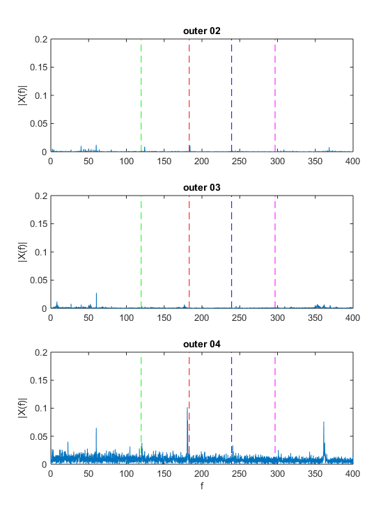

```matlab
%plot -s 560,750

T = time(2) - time(1);
Fs = 1/T;
N = length(time);
L = N/Fs;
t = 0:T:time(end);

% single-sided fft
oet2 = fft(out02marez)/N;
oet2ss = oet2(1:N/2+1);
oet2ss(2:end-1) = 2*oet2ss(2:end-1);

oet3 = fft(out03marez)/N;
oet3ss = oet3(1:N/2+1);
oet3ss(2:end-1) = 2*oet3ss(2:end-1);

oet4 = fft(out04marez)/N;
oet4ss = oet4(1:N/2+1);
oet4ss(2:end-1) = 2*oet4ss(2:end-1);

k = [0:N-1];
f = (Fs/N)*k;
fss = f(1:N/2+1);

% plot
subplot(3,1,1), plot([BSF,BSF],[0,0.2],'--g',[BPFO,BPFO],[0,0.2],'--r',[BDF,BDF],[0,0.2],'--b',[BPFI,BPFI],[0,0.2],'--m'),
hold on, plot(fss,abs(oet2ss)), hold off, xlim([0,400]), ylim([0,0.2]), ylabel('|X(f)|'), title('outer 02')

subplot(3,1,2), plot([BSF,BSF],[0,0.2],'--g',[BPFO,BPFO],[0,0.2],'--r',[BDF,BDF],[0,0.2],'--b',[BPFI,BPFI],[0,0.2],'--m'),
hold on, plot(fss,abs(oet3ss)), hold off, xlim([0,400]), ylim([0,0.2]), ylabel('|X(f)|'), title('outer 03')

subplot(3,1,3), plot([BSF,BSF],[0,0.2],'--g',[BPFO,BPFO],[0,0.2],'--r',[BDF,BDF],[0,0.2],'--b',[BPFI,BPFI],[0,0.2],'--m'),
hold on, plot(fss,abs(oet4ss)), hold off, xlim([0,400]), ylim([0,0.2]), xlabel('f'), ylabel('|X(f)|'), title('outer 04')
```

## 3.4. Inner Race

- innerace_fault $\implies$ [01 02 03 04]
  - 01 = 시간
  - 02 = 불균형이 있는 경우 (1X성분이 증가) 3.6g * 44.4mm
  - 03 = 불균형이 있으면서, 내륜결함이 있는 경우
  - 04 = 불균형이 있으면서, 내륜결함으로 구동 중 베어링이 파손된 경우

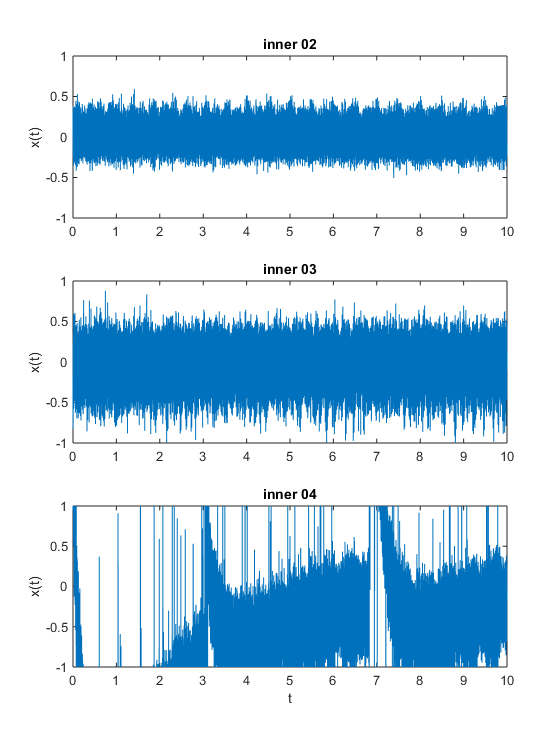

```matlab
%plot -s 560,750

filename = '.\data_files\innerrace_fault.mat';
data = load(filename);

time = data.inner(:,1);
in02 = data.inner(:,2);
in03 = data.inner(:,3);
in04 = data.inner(:,4);

subplot(3,1,1), plot(time,in02), xlim([0,10]), ylim([-1,1]), ylabel('x(t)'), title('inner 02')
subplot(3,1,2), plot(time,in03), xlim([0,10]), ylim([-1,1]), ylabel('x(t)'), title('inner 03')
subplot(3,1,3), plot(time,in04), xlim([0,10]), ylim([-1,1]), xlabel('t'), ylabel('x(t)'), title('inner 04')
```

```matlab
% smoothing using moving average (MA) model

windowsize = 5;
b = ones(1,windowsize)/windowsize;
a = 1;

in02ma = filter(b,a,in02);
in02mar = in02 - in02ma; % use residual

in03ma = filter(b,a,out03);
in03mar = in03 - in03ma;

in04ma = filter(b,a,in04);
in04mar = in04 - in04ma;
```

```matlab
% envelope analysis

in02mare = abs(hilbert(in02mar));
in03mare = abs(hilbert(in03mar));
in04mare = abs(hilbert(in04mar));

in02marez = in02mare - mean(in02mare); % remove dc offset
in03marez = in03mare - mean(in03mare);
in04marez = in04mare - mean(in04mare);
```

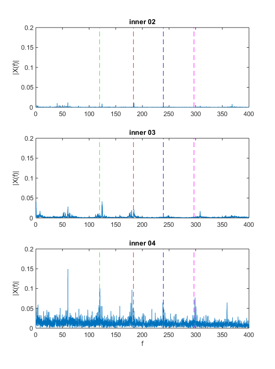

```matlab
%plot -s 560,750

T = time(2) - time(1);
Fs = 1/T;
N = length(time);
L = N/Fs;
t = 0:T:time(end);

% single-sided fft
iet2 = fft(in02marez)/N;
iet2ss = iet2(1:N/2+1);
iet2ss(2:end-1) = 2*iet2ss(2:end-1);

iet3 = fft(in03marez)/N;
iet3ss = iet3(1:N/2+1);
iet3ss(2:end-1) = 2*iet3ss(2:end-1);

iet4 = fft(in04marez)/N;
iet4ss = iet4(1:N/2+1);
iet4ss(2:end-1) = 2*iet4ss(2:end-1);

k = [0:N-1];
f = (Fs/N)*k;
fss = f(1:N/2+1);

% plot
subplot(3,1,1), plot([BSF,BSF],[0,0.2],'--g',[BPFO,BPFO],[0,0.2],'--r',[BDF,BDF],[0,0.2],'--b',[BPFI,BPFI],[0,0.2],'--m'),
hold on, plot(fss,abs(iet2ss)), hold off, xlim([0,400]), ylim([0,0.2]), ylabel('|X(f)|'), title('inner 02')

subplot(3,1,2), plot([BSF,BSF],[0,0.2],'--g',[BPFO,BPFO],[0,0.2],'--r',[BDF,BDF],[0,0.2],'--b',[BPFI,BPFI],[0,0.2],'--m'),
hold on, plot(fss,abs(iet3ss)), hold off, xlim([0,400]), ylim([0,0.2]), ylabel('|X(f)|'), title('inner 03')

subplot(3,1,3), plot([BSF,BSF],[0,0.2],'--g',[BPFO,BPFO],[0,0.2],'--r',[BDF,BDF],[0,0.2],'--b',[BPFI,BPFI],[0,0.2],'--m'),
hold on, plot(fss,abs(iet4ss)), hold off, xlim([0,400]), ylim([0,0.2]), xlabel('f'), ylabel('|X(f)|'), title('inner 04')
```

```matlab
%%javascript
$.getScript('https://kmahelona.github.io/ipython_notebook_goodies/ipython_notebook_toc.js')
```